# EDA Code Notebook

Kimberly Cardinale, Noelle Crichton, and William Kong

2025-07-17

## 1. Introduction

This exploratory analysis investigates potential connections between global energy commodity prices—specifically crude oil, coal, and natural gas—and the U.S. Producer Price Index (PPI) from 1992 to 2016. Rather than testing a specific hypothesis, our goal is to identify and understand trends, anomalies, and possible correlations that might inform deeper economic inquiry. In particular, we examine whether changes in commodity prices tend to lead or lag shifts in producer prices, a question with implications for inflation forecasting and policy responses.

Why focus on commodity prices? They play a central role in shaping the global economy. As key inputs in manufacturing, energy, and industrial production, they influence upstream costs that can ripple through supply chains and eventually surface in macroeconomic indicators like the PPI. By looking at these variables together over time, we can better understand how shocks in global energy markets—such as sudden spikes in crude oil—translate into domestic producer prices.

We draw on two publicly available datasets. The first, from the **International Monetary Fund (IMF)** and republished via the [“datasets” GitHub project](https://github.com/datasets/commodity-prices/tree/main), contains monthly prices for 53 commodities and 10 indexes from 1980 to 2016, indexed to 2005 = 100. From this dataset, we focus on the Crude Oil (Petroleum) Index, the Coal Index, and the Fuel Energy Index (used here as a proxy for natural gas due to limited standalone data). Because the data are aggregated globally, local market variations, such as differences between Brent and WTI crude, are not captured, which can mask important regional dynamics. Furthermore, the dataset was last updated in March of 2016, excluding recent disruptions like the COVID-19 pandemic and the 2021–2023 global energy crisis. These constraints mean that the patterns we observe reflect long-term global trends rather than recent, potentially more volatile market conditions.

The second dataset, sourced from the **U.S. Bureau of Labor Statistics** via FRED (series PPIACO), measures the average change over time in selling prices received by U.S. producers. While comprehensive for goods-producing sectors, it excludes services and imports, meaning it captures only part of the broader inflation picture. When paired with the IMF commodity data, however, the PPI offers a valuable perspective on how global energy price movements might filter into domestic production costs.

Below is a quick roadmap of the notebook to guide readers:

- **Section 2 — Reading Data in R** loads the IMF commodity series and the PPI series.
- **Section 3 — Forming the Core Data Frame and Data Cleaning** transforms, filters (1992-2016), and merges the commodity indices with the PPI.
- **Section 4 — Understanding the Dataset** provides summary statistics, histograms, and a time-series plot to describe distributions and trends.
- **Section 5 — Lead or Lag: Correlation Analysis** calculates static correlations, lagged correlations, and 12-month rolling correlations to assess the timing and strength of the relationships.
- **Section 6 — Conclusion** interprets our findings and discusses their broader implications.
- **Section 7 — References:** lists and cites the data sources used in this analysis.

## 2. Reading Data in R

```
## The raw commodity price and PPI datasets have been successfully loaded.
## Ready for data cleaning and merging in the next step.
```

## 3. Forming the Core Data Frame and Data Cleaning

### Cleaning the Commodity Data

We first begin our analysis at data wrangling, using the `tidyverse` package. With the two datasets loaded, we transform and merge them into a singular tabular dataset so that we can look at both the change in Commodity data and PPI data. We check the column names and then convert the Date column into proper date format using `ymd()` from the `lubridate` package.

We then filter the dataset to include only observations from January 1992 to June 2016, since earlier years contain missing values for Natural Gas. From the 64-column dataset, we isolate three key variables: Crude Oil, Natural Gas, and Coal. After selecting and renaming these variables for clarity, we prepare the cleaned energy dataset to be merged with the PPI dataset based on the shared Date variable. We preview the resulting structure using `head()`.

```
##         Date CrudeOil NaturalGas Coal
## 1 1992-01-01 32.76971   35.07449 39.5
## 2 1992-02-01 33.00494   35.08234 39.5
## 3 1992-03-01 32.48635   34.62676 39.5
## 4 1992-04-01 34.91216   36.69555 39.5
## 5 1992-05-01 36.55289   38.19939 39.5
## 6 1992-06-01 39.10037   40.39558 39.5
```

### Cleaning and Merging PPI Data

We then apply similar cleaning steps to the PPI dataset, filtering it to include observations from 1992 to 2016 and converting the date column to match the format used in the commodity data. After standardizing both datasets, we merge them by the Date column. We confirm the structure of the resulting merged dataset using head().

```
##         Date CrudeOil NaturalGas Coal   PPI
## 1 1992-01-01 32.76971   35.07449 39.5 115.6
## 2 1992-02-01 33.00494   35.08234 39.5 116.0
## 3 1992-03-01 32.48635   34.62676 39.5 116.1
## 4 1992-04-01 34.91216   36.69555 39.5 116.3
## 5 1992-05-01 36.55289   38.19939 39.5 117.2
## 6 1992-06-01 39.10037   40.39558 39.5 118.0
```

## 4. Understanding the Dataset: Summary Statistics and Distributions

After obtaining the datasets, we start by developing an initial understanding of the data’s distribution, central tendencies, and trends over time. To achieve this, we compute summary statistics to gain a foundational understanding of the data, plot histograms to visualize the distributions of different values, and create time-series graphs to visualize trends over time.

We first examine the basic summary statistics to understand the overall structure and range of values. We use the `summary()` function to get a view of each variable’s distribution, including minimum, maximum, mean, and quartile values.

```r
# Display summary statistics for each variable in the merged dataset
summary(merged_data)
```

```
##       Date               CrudeOil        NaturalGas          Coal
##  Min.   :1992-01-01   Min.   : 19.54   Min.   : 22.09   Min.   : 24.00
##  1st Qu.:1998-02-08   1st Qu.: 35.95   1st Qu.: 37.89   1st Qu.: 31.40
##  Median :2004-03-16   Median : 61.10   Median : 62.05   Median : 43.11
##  Mean   :2004-03-16   Mean   : 91.25   Mean   : 91.74   Mean   : 57.94
##  3rd Qu.:2010-04-23   3rd Qu.:139.77   3rd Qu.:138.77   3rd Qu.: 77.55
##  Max.   :2016-06-01   Max.   :249.66   Max.   :249.61   Max.   :195.19
##       PPI
##  Min.   :115.6
##  1st Qu.:127.0
##  Median :143.9
##  Mean   :155.3
##  3rd Qu.:184.9
##  Max.   :208.3
```

The summary statistics reveal key characteristics of the dataset. Between 1992 and 2016, the three energy commodity indices—Crude Oil, Natural Gas, and Coal—each range from roughly 20 to 250. Coal has a slightly lower maximum value at around 195, but overall the three indices are on a comparable scale. This similarity in magnitude allows for easier visual comparison without the need for normalization, guiding us to proceed with the visualizations.

### Distribution Visualization

To further explore the dataset, we now examine how these variables are distributed over time using a histogram and a time-series graph. Before plotting, we reshape the data (via `tidyr` from the `tidyverse` package) into a long format to facilitate multi-series visualizations.

```
## tibble [1,176 × 3] (S3: tbl_df/tbl/data.frame)
##  $ Date : Date[1:1176], format: "1992-01-01" "1992-01-01" ...
##  $ Index: chr [1:1176] "CrudeOil" "NaturalGas" "Coal" "PPI" ...
##  $ Price: num [1:1176] 32.8 35.1 39.5 115.6 33 ...
```

The histogram explores the range and variability in price levels for each commodity and for the PPI. To do this, we use histograms with 30 bins, which group the continuous price data into intervals and display the frequency of observations within each range. This helps us assess the distribution shape and compare the spread across variables.

We begin by reshaping the dataset into a long format for easier plotting:

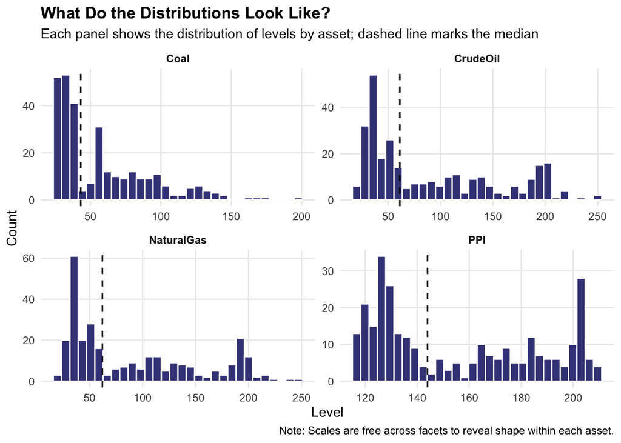

The resulting histograms reveal distinct distribution patterns across the four variables. In each panel, the x-axis represents the price or index value, while the y-axis shows the frequency (number of months) that values fall within each bin.

Both Crude Oil and Natural Gas exhibit strongly right-skewed distributions, with most observations concentrated at lower price levels and occasional spikes. This suggests these commodities typically remain in a moderate price range but experience sharp surges during certain periods, likely in response to global shocks or supply disruptions.

PPI also appears bimodal, with clusters around 130 and again near 200. Unlike the commodity prices, PPI shows less variance overall. The twin peaks may correspond to broader macroeconomic events, such as the post-2008 financial stimulus or the recovery period that followed, suggesting how changes in upstream costs tend to manifest more gradually in producer prices.

### Time Series Analysis of Longitudinal Price Changes in Energy Commodities

With an understanding of the price distributions, our second visualization focuses on how the commodity indices and PPI fluctuate over time. To analyze these long-term trends, we create line plots showing time series data. This visualization helps us identify major global events or market shifts that triggered sudden price changes, as well as reveal underlying patterns or cycles in the data.

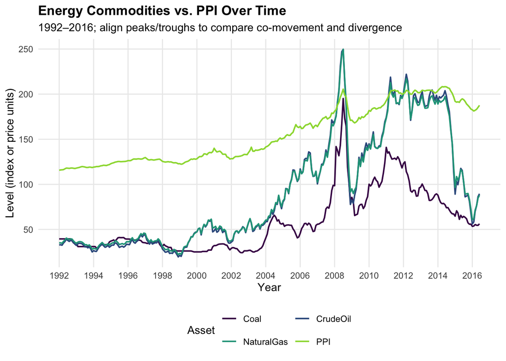

This graph illustrates how each energy commodity and the PPI evolved from 1992 to 2016. Crude Oil and Natural Gas display highly similar patterns—both exhibit sharp price increases and drops, with major volatility around 2008 (the global financial crisis) and 2011–2014 (the post-crisis stimulus period and geopolitical tensions such as the Arab Spring). This close alignment suggests that these two commodities are similarly sensitive to global supply and demand shocks.

Coal, while still showing some correlation—particularly around 2008—tends to lag behind the other two commodities and exhibits a slower response to global events. Its price pattern is less volatile overall, which may reflect different market structures, regulatory environments, or shifts in demand over time.

Building on the basic statistical summary, histograms, and time-series analysis, we now have a solid foundation to quantify correlations and explore potential lead–lag relationships between Commodity Prices and the PPI.

## 5. Lead or Lag: Correlation Analysis

Our previous section investigates the of individual variables — each commodity index and the PPI — over time. To gain a better understanding of how commodity prices influence the PPI, it is essential to analyze the between these two variables. Specifically, we want to assess the strength of the relationship between each commodity index and the PPI, as well as the time lag involved in the transmission of price changes from commodities to producer prices. To this goal, we first measure the overall strength and direction of the relationships using static correlations, then understand the potential lead–lag effects using lagged correlations, and tracks how the correlation changes over time to identify periods of stronger or weaker association through 12-month rolling correlations analysis.

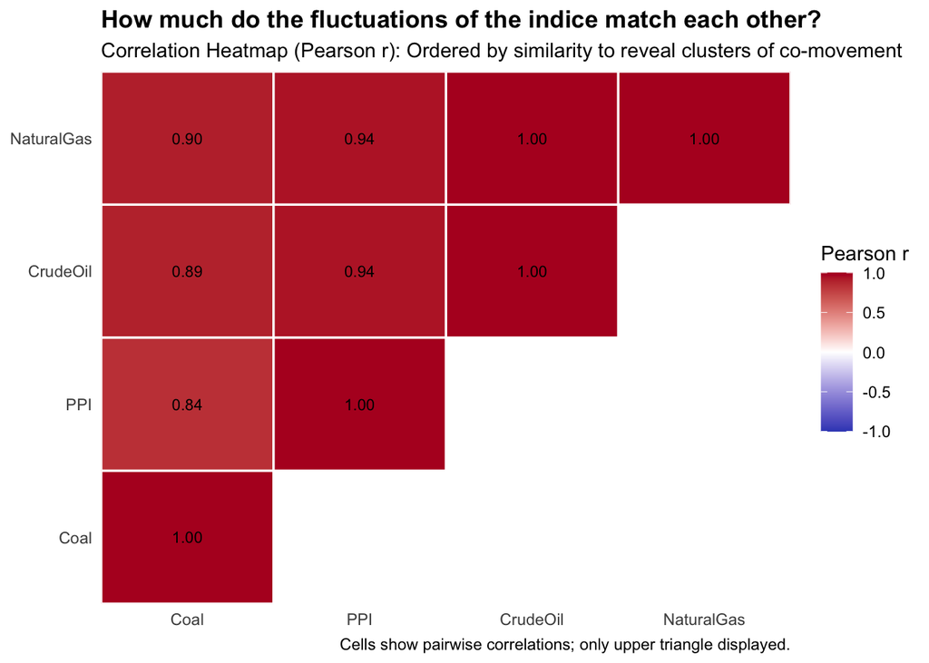

```r
# Correlation + order variables by clustering
vars <- c("CrudeOil", "NaturalGas", "Coal", "PPI")
cor_matrix <- merged_data %>%
  select(all_of(vars)) %>%
  cor(use = "complete.obs")

# Order by hierarchical clustering for easier pattern reading
hc_order <- rownames(cor_matrix)[hclust(dist(cor_matrix))$order]
cor_melted <- melt(cor_matrix, varnames = c("Var1", "Var2"), value.name = "Corr") %>%
  mutate(
    Var1 = factor(Var1, levels = hc_order),
    Var2 = factor(Var2, levels = hc_order)
  ) %>%
  # keep upper triangle including diagonal to reduce redundancy
  dplyr::filter(as.numeric(Var1) <= as.numeric(Var2))

ggplot(cor_melted, aes(Var1, Var2, fill = Corr)) +
  geom_tile(color = "white", linewidth = 0.6) +
  scale_fill_gradient2(
    low = "#3B4CC0", mid = "white", high = "#B40426",
    midpoint = 0, limits = c(-1, 1), oob = squish, name = "Pearson r"
  ) +
  geom_text(aes(label = sprintf("%.2f", Corr)), size = 3) +
  scale_x_discrete(NULL, expand = c(0, 0)) +
  scale_y_discrete(NULL, expand = c(0, 0)) +
  labs(
    title = "How much do the fluctuations of the indice match each other?",
    subtitle = "Correlation Heatmap (Pearson r): Ordered by similarity to reveal clusters of co-movement",
    caption = "Cells show pairwise correlations; only upper triangle displayed."
  ) +
  theme_minimal(base_size = 11) +
  theme(
    panel.grid = element_blank(),
    plot.title = element_text(face = "bold"),
    legend.position = "right"
  )
```

The correlation heat map reveals that all three energy indices exhibit strong positive correlations with the PPI. Specifically, Crude Oil and Natural Gas both have correlations of 0.94 with the PPI. This result indicates that both play fundamental roles in industrial production. Price fluctuations in these commodities have a direct association with changes in producer prices. Coal, on the other hand, has a weaker correlation of 0.84, which may reflect its declining role in industrial production due to evolving energy policies and shifting fuel preferences over time.

Notably, Natural Gas and Crude Oil exhibit a perfect correlation of 1. This unusual finding suggests either a strong structural link causing their prices to move in sync or potential issues with the data accuracy.

The static analysis, however, does not reveal the dynamic nature of the Commodity Price and PPI relationship. Therefore, we move on to examine the timing of these relationships. Specifically, we want to investigate whether changes in commodity prices tend to lead, coincide with, or lag changes in the PPI. To explore this, we first employ the method of **lagged correlation analysis**, which provides us with data to show the correlations between each commodity index and the PPI across preceding, current, and following months. This approach enables us to differentiate between leading, synchronous, and lagging effects of commodity prices on the PPI, as well as identify which commodity is the most reliable predictor of future producer price movements.

```r
lagged_df <- merged_data %>%
  select(Date, CrudeOil, NaturalGas, Coal, PPI) %>%
  mutate(
    CrudeOil_lag1  = dplyr::lag(CrudeOil, 1),
    CrudeOil_lead1 = dplyr::lead(CrudeOil, 1),
    NaturalGas_lag1  = dplyr::lag(NaturalGas, 1),
    NaturalGas_lead1 = dplyr::lead(NaturalGas, 1),
    Coal_lag1  = dplyr::lag(Coal, 1),
    Coal_lead1 = dplyr::lead(Coal, 1)
  )

# Build lag factor once
lags <- factor(c("-1 month", "0 month", "+1 month"),
               levels = c("-1 month", "0 month", "+1 month"))

cor_results <- tibble(
  Commodity = rep(c("Crude Oil", "Natural Gas", "Coal"), each = 3),
  Lag       = rep(lags, times = 3),
  Correlation = c(
    cor(lagged_df$CrudeOil_lag1,  lagged_df$PPI, use = "complete.obs"),
    cor(lagged_df$CrudeOil,       lagged_df$PPI, use = "complete.obs"),
    cor(lagged_df$CrudeOil_lead1, lagged_df$PPI, use = "complete.obs"),

    cor(lagged_df$NaturalGas_lag1,  lagged_df$PPI, use = "complete.obs"),
    cor(lagged_df$NaturalGas,       lagged_df$PPI, use = "complete.obs"),
    cor(lagged_df$NaturalGas_lead1, lagged_df$PPI, use = "complete.obs"),

    cor(lagged_df$Coal_lag1,  lagged_df$PPI, use = "complete.obs"),
    cor(lagged_df$Coal,       lagged_df$PPI, use = "complete.obs"),
    cor(lagged_df$Coal_lead1, lagged_df$PPI, use = "complete.obs")
  )
)

# Cleaner table for print
kable(
  cor_results %>% mutate(Correlation = round(Correlation, 3)),
  caption = "Lagged correlations of commodities vs. PPI"
)
```

Lagged correlations of commodities vs. PPI

| Commodity | Lag | Correlation |
| --- | --- | --- |
| Crude Oil | -1 month | 0.942 |
| Crude Oil | 0 month | 0.938 |
| Crude Oil | +1 month | 0.929 |
| Natural Gas | -1 month | 0.946 |
| Natural Gas | 0 month | 0.942 |
| Natural Gas | +1 month | 0.934 |
| Coal | -1 month | 0.840 |
| Coal | 0 month | 0.838 |
| Coal | +1 month | 0.833 |

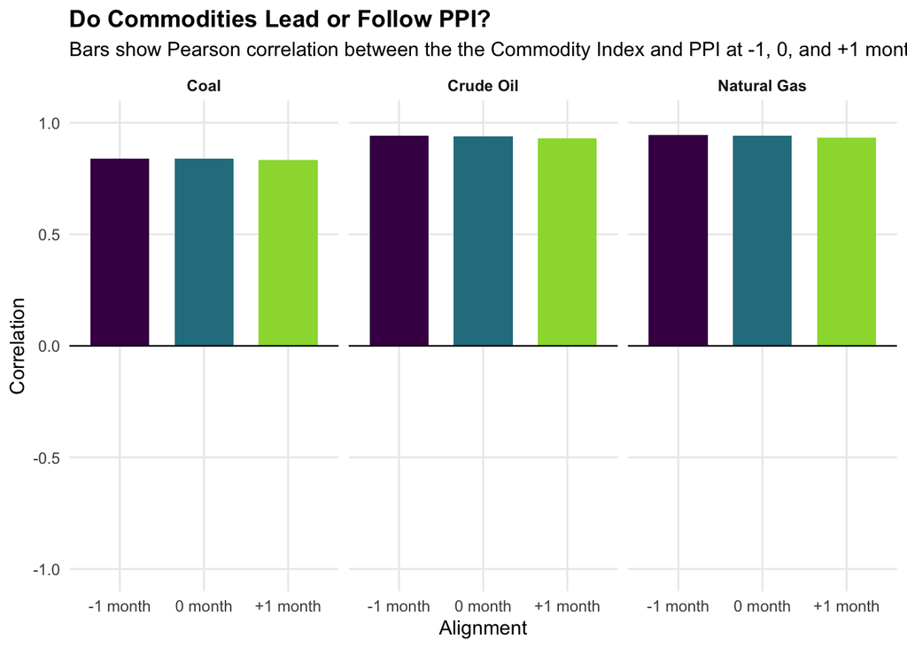

```r
# Quick visual: small-multiple bars to surface the key pattern at a glance
ggplot(cor_results, aes(x = Lag, y = Correlation, fill = Lag)) +
  geom_col(width = 0.7, show.legend = FALSE) +
  facet_wrap(~ Commodity, nrow = 1) +
  geom_hline(yintercept = 0, linewidth = 0.4) +
  scale_y_continuous(labels = label_number(accuracy = 0.1), limits = c(-1, 1)) +
  scale_fill_viridis_d(end = 0.85, option = "D") +
  labs(
    title = "Do Commodities Lead or Follow PPI?",
    subtitle = "Bars show Pearson correlation between the the Commodity Index and PPI at -1, 0, and +1 month ",
    x = "Alignment",
    y = "Correlation"
  ) +
  theme_minimal(base_size = 11) +
  theme(
    panel.grid.minor = element_blank(),
    strip.text = element_text(face = "bold"),
    plot.title = element_text(face = "bold")
  )
```

The results indicate that for Crude Oil, Natural Gas, and Coal, the strongest correlation with the PPI occurs when the commodity prices lead by one month. Natural Gas exhibits the highest correlation at this lag (0.946), followed closely by Crude Oil (0.942), while Coal shows a substantially lower correlation of 0.840. These findings suggest that Crude Oil and Natural Gas both exhibit strong ***leading** relationships with the PPI, meaning that movements in their prices may serve as effective early indicators of shifts in producer prices—and, by extension, inflationary pressures. In contrast, Coal appears to have more limited predictive value in this regard.

While this analysis offers an aggregate view of the timing and strength of correlations, these relationships are not fixed. Correlations between commodity prices and the PPI can shift in response to changing market dynamics. To capture these fluctuations, we turn to **rolling correlation analysis**, which tracks how the strength and direction of correlations evolve over time. This method allows us to pinpoint periods when the predictive relationship between commodity indices and the PPI becomes particularly strong or weak.

Specifically, the rolling correlation is calculated using a 12-month moving window. By averaging the correlation within each window and sequentially shifting it forward by one month, we smooth short-term noise and uncover meaningful temporal trends in the link between commodity prices and producer price inflation.

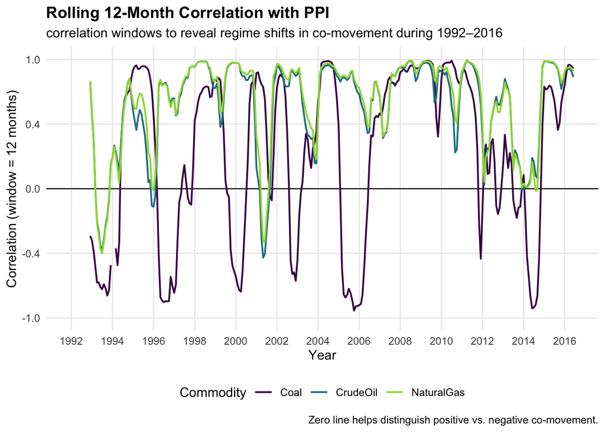

```r
roll_cor <- function(x, y, window = 12) {
  rollapplyr(
    seq_along(x),
    width = window,
    FUN = function(i) cor(x[i:(i + window - 1)], y[i:(i + window - 1)], use = "complete.obs"),
    by = 1, fill = NA
  )
}

merged_data <- merged_data %>%
  mutate(
    roll_cor_crude = roll_cor(CrudeOil,   PPI, 12),
    roll_cor_gas   = roll_cor(NaturalGas, PPI, 12),
    roll_cor_coal  = roll_cor(Coal,       PPI, 12)
  )

roll_long <- merged_data %>%
  select(Date, roll_cor_crude, roll_cor_gas, roll_cor_coal) %>%
  rename(CrudeOil = roll_cor_crude, NaturalGas = roll_cor_gas, Coal = roll_cor_coal) %>%
  pivot_longer(-Date, names_to = "Commodity", values_to = "RollingCorrelation")

ggplot(roll_long, aes(x = Date, y = RollingCorrelation, color = Commodity)) +
  geom_hline(yintercept = 0, linewidth = 0.4) +
  geom_line(linewidth = 0.7) +
  scale_color_viridis_d(end = 0.85, option = "D") +
  scale_x_date(date_breaks = "2 years", date_labels = "%Y") +
  scale_y_continuous(limits = c(-1, 1), labels = label_number(accuracy = 0.2)) +
  labs(
    title = "Rolling 12-Month Correlation with PPI",
    subtitle = "correlation windows to reveal regime shifts in co-movement during 1992–2016",
    x = "Year",
    y = "Correlation (window = 12 months)",
    color = "Commodity",
    caption = "Zero line helps distinguish positive vs. negative co-movement."
  ) +
  theme_minimal(base_size = 11) +
  theme(
    legend.position = "bottom",
    panel.grid.minor = element_blank(),
    plot.title = element_text(face = "bold")
  )
```

In contrast, Coal exhibits far greater volatility in its correlation with the PPI throughout the entire period. While it mirrors the trends of Crude Oil and Natural Gas between 1993–1996 and 2006–2012, its correlation fluctuates sharply at other times, ranging from strongly negative (approaching -1) to strongly positive (approaching 1). This inconsistency suggests that the role that Coal plays in industrial production may have declined or become more context-dependent over time.

Notably, in the post-2010 period, all three indices exhibit a marked decline in correlation with the PPI: Crude Oil and Natural Gas fall to around zero, while Coal reaches nearly -1. However, this trend reverses sharply in 2015, when all three commodities suddenly display renewed positive correlations above 0.5.

## 6. Conclusion

However, our current EDA has raised further questions. So far, we have focused on the relationship between energy-related Commodity Prices and the PPI, which are just part of the broader inflation transmission mechanism involving multiple factors. We have expanded this initial exploration into a broader research project that focuses specifically on the Consumer Price Index (CPI). Key components in this mechanism include Commodity Prices as the upstream indicator, PPI as the midstream indicator, and CPI as the downstream indicator. Our analysis has identified a lead–lag relationship between Commodity Prices and PPI for the previous and following month. But how does this relationship extend over longer future periods? Additionally, how do Commodity Prices, PPI, and CPI interact with each other? Can we develop predictive models for these three variables based on sudden changes in upstream Commodity Prices? Addressing these questions would provide a more comprehensive and quantified understanding of the inflation transmission process.

## 7. References

International Monetary Fund. 2016. *Primary Commodity Price System – Monthly Prices*. Retrieved from https://github.com/datasets/commodity-prices

U.S. Bureau of Labor Statistics. 2016. *Producer Price Index for All Commodities (PPIACO)*. Federal Reserve Bank of St. Louis. Retrieved from https://fred.stlouisfed.org/series/PPIACO